# PD 4

Witold Merkel

12 04 2019

# 1 Wporowadzenie

Celem tej pracy jest pokazanie procesu zapoznawczego z SVM (Support Vector Machine). Do wykonania tego zadania zdecydowałem się użyć zbioru z `openml` o nazwie `credit_g` oraz oczywiście `apartments` z pakietu `DALEX`. Dla pierwszego zbioru będę robił klasyfikację przewidującą klasę kredytową, a dla drugiego będę poprzez regresją przewidywał cenę mieszkania za metr kwadratowy.

# 2 Dopasowanie modeli

## 2.1 Regresja

```r
regr_task <- makeRegrTask(id = "task", data = apartments, target = "m2.price")
regr_lrn <- makeLearner("regr.svm")
model_regr <- mlr::train(regr_lrn, regr_task)
predict_regr <- predict(model_regr, newdata = apartments_test, type='response')
perf_regr <- performance(predict_regr, measures = list(rmse))
perf_regr
```

```
##    rmse
## 160.901
```

## 2.2 Klasyfikacja

```r
classif_task <- makeClassifTask(id = "task", data = credit_g_train, target = "class")
classif_lrn <- makeLearner("classif.svm", predict.type = "prob")
model_classif <- mlr::train(classif_lrn, classif_task)
predict_classif <- predict(model_classif, newdata = credit_g_test, type='response')
perf_classif <- performance(predict_classif, measures = list(acc))
perf_classif
```

```
##   acc
## 0.752
```

Powyżej dopasowujemy modele `SVM` z domyślnymi parametrami. Ustaliliśmy też w jaki sposób będziemy oceniać modele, mianowicie dla regresji użyjemy `RMSE` (Root Mean Square Error), aby mieć te same jednostki co szukana wartość, a dla klasyfikacji `ACC` (Accuracy).

# 3 Sprawdzenie służności uwag o skalowaniu danych

Z dokumentacji wynika, że model svm ma argument `scale` domyślnie ustawiony na `TRUE`, więc dane są skalowane. Sprawdźmy co się stanie z jakością predykcji, jeżeli ustawimy ten parametr na `FALSE`. Skalowanie o jakim tu mowa to przekształcenie, tak aby średnia była 0, a wariancja 1.

## 3.1 Regresja

```r
regr_task_no <- makeRegrTask(id = "task", data = apartments, target = "m2.price")
regr_lrn_no <- makeLearner("regr.svm", par.vals = list(scale = FALSE))
model_regr_no <- mlr::train(regr_lrn_no, regr_task_no)
predict_regr_no <- predict(model_regr_no, newdata = apartments_test, type='response')
perf_regr_no <- performance(predict_regr_no, measures = list(rmse))
perf_regr_no
```

```
##     rmse
## 908.7186
```

## 3.2 Klasyfikacja

```r
classif_task_no <- makeClassifTask(id = "task", data = credit_g_train, target = "class")
classif_lrn_no <- makeLearner("classif.svm", predict.type = "prob", par.vals = list(scale = FALSE))
model_classif_no <- mlr::train(classif_lrn_no, classif_task_no)
predict_classif_no <- predict(model_classif_no, newdata = credit_g_test, type='response')
perf_classif_no <- performance(predict_classif_no, measures = list(acc))
perf_classif_no
```

```
##   acc
## 0.688
```

## 3.3 Wnioski

Łatwo można zauważyć, że `Accuracy` spadło, co oznacza, że model jest gorszy. Widać też, że pierwiastek błędu średniokwadratowego wzrósł, co również mówi nam, że model się pogorszył. W związku z tym, że w tej pracy oprócz zapoznania się z `svm`chciałby znaleźć najlepszy zetaw hiperparametrów, będziemy szukać z pośród takich dla których `scale` jest ustawione na `TRUE`, czyli domyślnie. Widzimy zatem, że artykuł mówił prawdę o skalowaniu.

# 4 Szukanie najlepszego zestawów hiperparametrów

Optymalizaje hiperparametrów wykonamy przy pomocy grid’a, punkty z niego będą wybierane losowo, aby spełnić założenia zadania. Po research’u doszedłem do wniosku, że najwiekszy sens ma skupienie się na trzech hiperparametrach: `cost`, `tolerance` i `gamma`.

## 4.1 Regresja

```r
params <- makeParamSet(
  makeNumericParam("cost", lower = 0, upper = 3),
  makeNumericParam("gamma", lower = 0.0001, upper = 1),
  makeNumericParam("tolerance", lower = 0.0005, upper = 0.05))
ctrl <- makeTuneControlRandom(maxit = 200)
regression_best <- tuneParams("regr.svm", task = regr_task, resampling = cv,
                 par.set = params, control = ctrl, show.info = FALSE, measures = list(rmse))
regression_best
```

```
## Tune result:
## Op. pars: cost=2.32; gamma=0.0366; tolerance=0.00264
## rmse.test.rmse=152.7499802
```

```r
regr_lrn_hyper <- makeLearner("regr.svm", par.vals = list(cost = regression_best$x$cost, gamma = regression_best$x$gamma,
                                                          tolerance = regression_best$x$tolerance))
model_regr_hyper <- mlr::train(regr_lrn_hyper, regr_task)
```

## 4.2 Klasyfikacja

```r
classification_best <- tuneParams("classif.svm", task = classif_task, resampling = cv,
                 par.set = params, control = ctrl, show.info = FALSE, measures = list(acc))
classification_best
```

```
## Tune result:
## Op. pars: cost=2.63; gamma=0.0554; tolerance=0.00553
## acc.test.mean=0.7666667
```

```r
classif_lrn_hyper <- makeLearner("classif.svm", predict.type = "prob",par.vals = list(cost = classification_best$x$cost, gamma = classification_best$x$gamma,
                                                          tolerance = classification_best$x$tolerance))
model_classif_hyper <- mlr::train(classif_lrn_hyper, classif_task)
```

Powyżej znajdujemy jak najlepsze parametry dla obu modeli oraz szkolimy modele z tymi parametrami.

# 5 randomForest

W tym rozdziale zrobimy modele `randomForest`.

## 5.1 Regresja

```r
regr_lrn_rf <- makeLearner("regr.randomForest")
model_regr_rf <- mlr::train(regr_lrn_rf, regr_task)
predict_regr_rf <- predict(model_regr_rf, newdata = apartments_test, type='response')
perf_regr_rf <- performance(predict_regr_rf, measures = list(rmse))
perf_regr_rf
```

```
##     rmse
## 285.8814
```

## 5.2 Klasyfikacja

```r
classif_lrn_rf <- makeLearner("classif.randomForest", predict.type = "prob")
model_classif_rf <- mlr::train(classif_lrn_rf, classif_task)
predict_classif_rf <- predict(model_classif_rf, newdata = credit_g_test, type='response')
perf_classif_rf <- performance(predict_classif_rf, measures = list(acc))
perf_classif_rf
```

```
##  acc
## 0.76
```

Jak widzimy, w obu przypadkach wyniki są gorsze od tych otrzymanych dzięki strojeniu hiperparametrów dla `SVM`, jednak warto przyjżeć się bliżej temu co się dzieje.

# 6 Porównanie wyników przy użyciu biblioteki DALEX

Najpierw musimy stworzyć explainery dla każdego modelu, a dopiero potem będziemy w stanie robić wykresy.

## 6.1 Tworzenie expleinerów

```r
custom_predict <- function(object, newdata) {pred <- predict(object, newdata=newdata)
                                              response <- pred$data$response
                                              return(response)}
regr_explainer <- explain(model_regr, data = apartmentsTest, y = apartmentsTest$m2.price, predict_function = custom_predict, label = 'svm')
regr_explainer_hyper <- explain(model_regr_hyper, data = apartmentsTest, y = apartmentsTest$m2.price, predict_function = custom_predict, label = 'svm_hyper')
regr_explainer_rf <- explain(model_regr_rf, data = apartmentsTest, y = apartmentsTest$m2.price, predict_function = custom_predict, label = 'rf')
```

```r
custom_predict_classif <- function(object, newdata) {pred <- predict(object, newdata=newdata)
                                              response <- pred$data[,3]
                                              return(response)}
classif_explainer <- explain(model_classif, data = credit_g_test, y = credit_g_test$class, predict_function = custom_predict_classif, label = 'svm')
classif_explainer_hyper <- explain(model_classif_hyper, data = credit_g_test, y = credit_g_test$class, predict_function = custom_predict_classif, label = 'svm_hyper')
classif_explainer_rf <- explain(model_classif_rf, data = credit_g_test, y = credit_g_test$class, predict_function = custom_predict_classif, label = 'rf')
```

## 6.2 PDP

### 6.2.1 Regresja

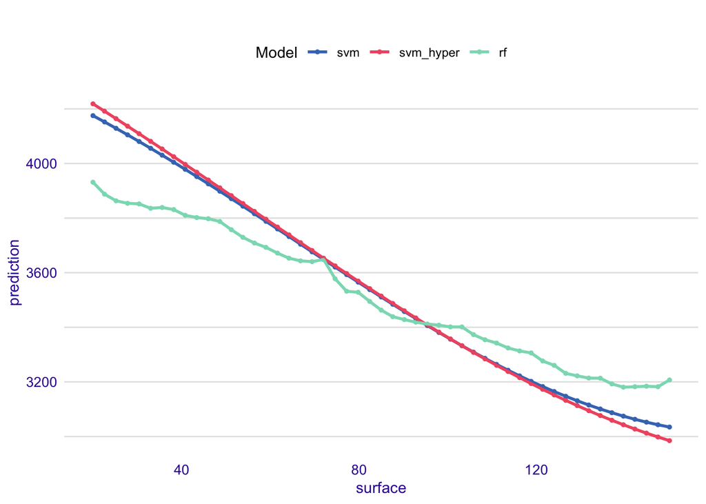

```r
regr_pdp <- variable_response(regr_explainer, variable = "surface", type = "pdp")
regr_pdp_hyper <- variable_response(regr_explainer_hyper, variable = "surface", type = "pdp")
regr_pdp_rf <- variable_response(regr_explainer_rf, variable = "surface", type = "pdp")
plot(regr_pdp, regr_pdp_hyper, regr_pdp_rf)
```

### 6.2.2 Klasyfikacja

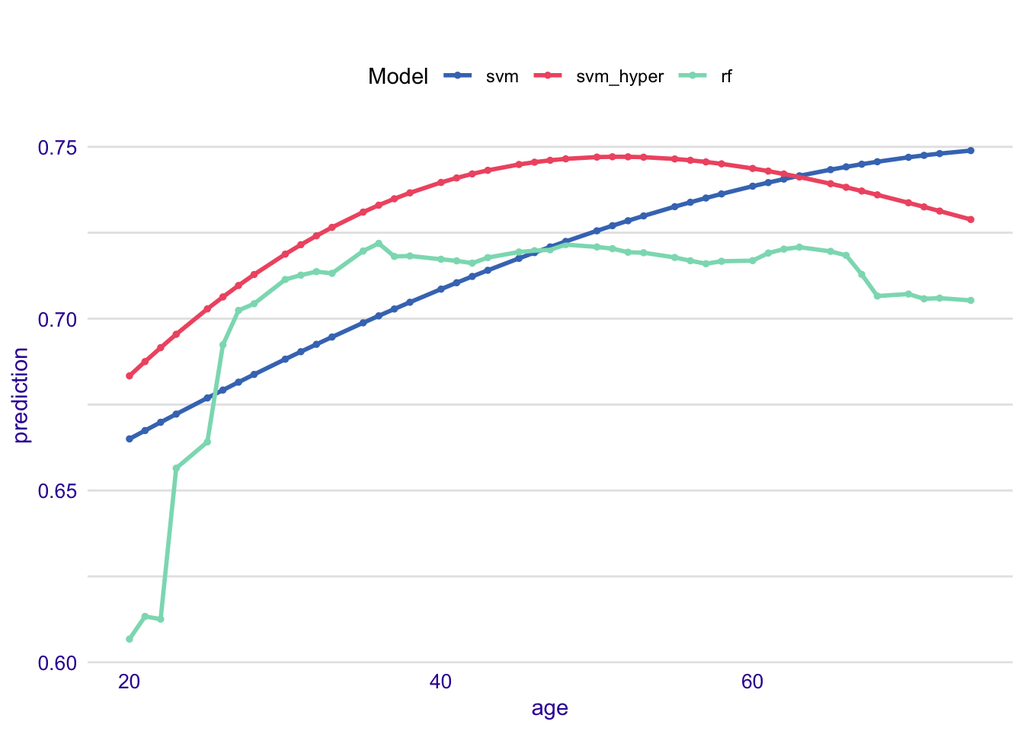

```r
classif_pdp <- variable_response(classif_explainer, variable = "age", type = "pdp")
classif_pdp_hyper <- variable_response(classif_explainer_hyper, variable = "age", type = "pdp")
classif_pdp_rf <- variable_response(classif_explainer_rf, variable = "age", type = "pdp")
plot(classif_pdp, classif_pdp_hyper, classif_pdp_rf)
```

## 6.3 ALE

### 6.3.1 Regresja

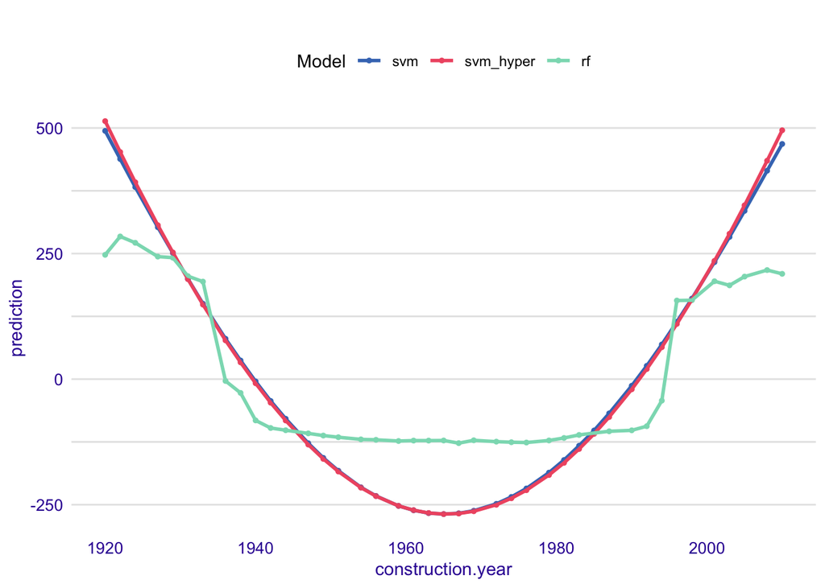

```r
regr_ale <- variable_response(regr_explainer, variable = "construction.year", type = "ale")
regr_ale_hyper <- variable_response(regr_explainer_hyper, variable = "construction.year", type = "ale")
regr_ale_rf <- variable_response(regr_explainer_rf, variable = "construction.year", type = "ale")
plot(regr_ale, regr_ale_hyper, regr_ale_rf)
```

### 6.3.2 Klasyfikacja

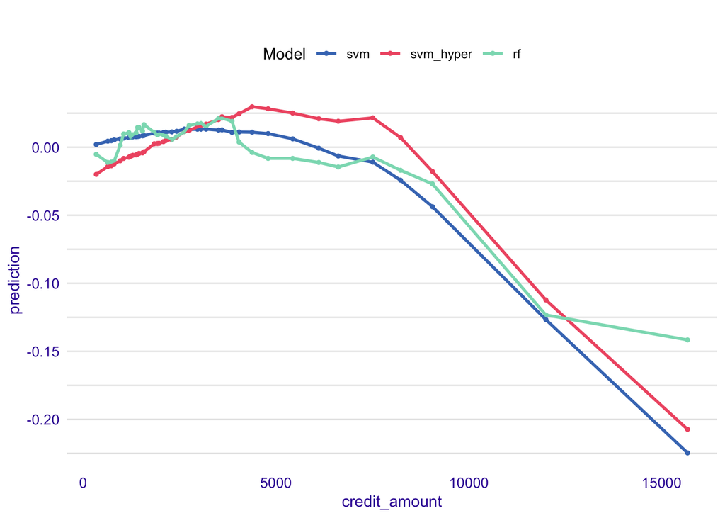

```r
classif_ale <- variable_response(classif_explainer, variable = "credit_amount", type = "ale")
classif_ale_hyper <- variable_response(classif_explainer_hyper, variable = "credit_amount", type = "ale")
classif_ale_rf <- variable_response(classif_explainer_rf, variable = "credit_amount", type = "ale")
plot(classif_ale, classif_ale_hyper, classif_ale_rf)
```

## 6.4 Rozkład rezydułów

### 6.4.1 Regresja

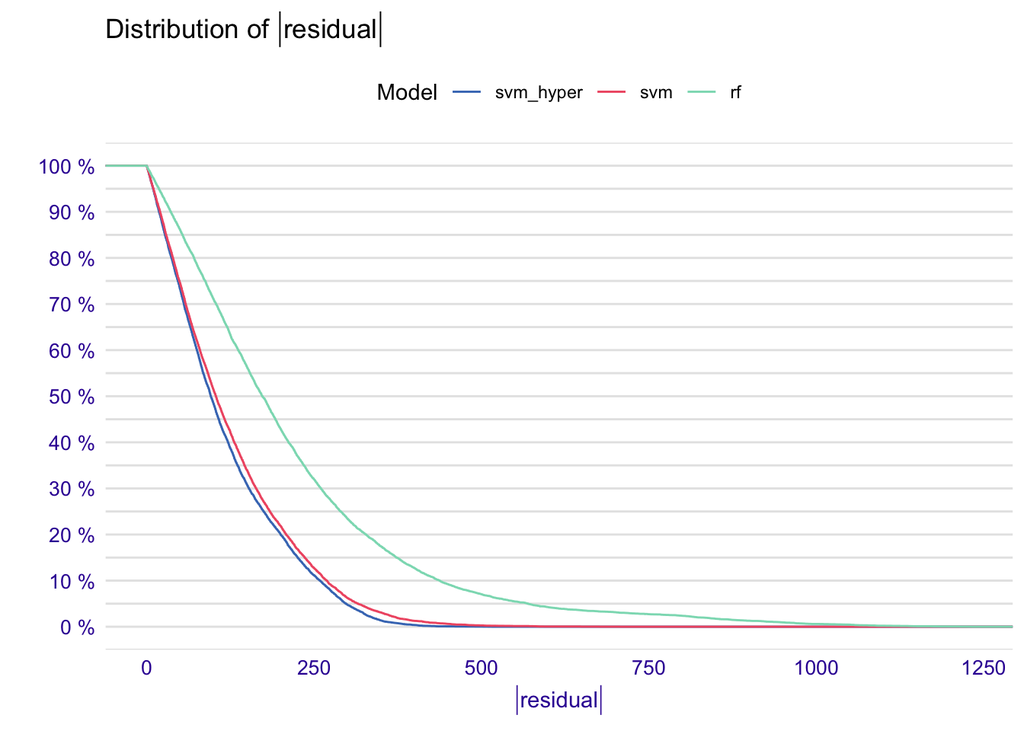

```r
plot(model_performance(regr_explainer), model_performance(regr_explainer_hyper), model_performance(regr_explainer_rf))
```

# 7 Podsumowanie

Widać z wyników otrzymanych przez konkretne modele, że strojenie hiperparametrów niewiele pomogło, co raczej jest logiczne, ponieważ ktoś myślał jak ustawiał domyślne oraz głównie dlatego, że w testach nie mogłem umieścić za dużych wartości czy dużej ilości prób ze względu na ograniczenia technologiczne.

Na wykresach widać, że `randomForest` działa inaczej niż `svm`. Widoczne również jest to że dwa przypadki `svm` są do siebie bardzo podobne w przypadku regresji, ale już nie aż tak podobne w przypadku klasyfikacji.